# Analysis3

Sophia Drewry

11/4/2021

This script loads the cleaned and processed data to perform some formal statistical fitting This analysis will focus on the continuous outcome “BodyTemp” with machine learning models

```r
# load needed packages. make sure they are installed or else...
library(dplyr) #for data processing
library(here) #to set paths
library(tidymodels) #to fit models
library(rpart)
```

```r
library(rpart.plot)
library(glmnet)
library(ranger)
library(future)
library(parallel)
library(doParallel)
```

##Load data

```r
# note the use of the here() package and not absolute paths
dataSPOT <- here::here("data","processed_data","processeddta.rds")
# load data.
processeddta <-readRDS(dataSPOT)
```

## Data splitting

Here we are going to split the data randomly into training and testing subsets - Training data will be used to fit the model. - Testing set will be used to evaluate the model.

```r
# Setting a seed for random number generation so if this analysis is reproduced, the same random set will be generated
set.seed(123)
# Subsetting 70% of data into training and 20% of data into testing
# We using Body Temp to stratify
data_split <- initial_split(processeddta, prop = .7, strata = "BodyTemp")
# Creating training data
train_data <- training(data_split)
# Creating testing data
test_data  <- testing(data_split)
```

## 5-fold cross-validation, 5x repeated

```r
# Creating a resample object for our trainng data
set.seed(123)
folds <- vfold_cv(train_data, v = 5, repeats = 5, strata = "BodyTemp")
folds
```

```
## #  5-fold cross-validation repeated 5 times using stratification
## # A tibble: 25 × 3
##    splits            id      id2
##    <list>            <chr>   <chr>
##  1 <split [405/103]> Repeat1 Fold1
##  2 <split [405/103]> Repeat1 Fold2
##  3 <split [406/102]> Repeat1 Fold3
##  4 <split [408/100]> Repeat1 Fold4
##  5 <split [408/100]> Repeat1 Fold5
##  6 <split [405/103]> Repeat2 Fold1
##  7 <split [405/103]> Repeat2 Fold2
##  8 <split [406/102]> Repeat2 Fold3
##  9 <split [408/100]> Repeat2 Fold4
## 10 <split [408/100]> Repeat2 Fold5
## # … with 15 more rows
```

/////////////////////////////////////////////////////////////////////////////// ## Setting workflows & training models: Model 1 Setting up lr.mod that will be used for the rest of the excersise

```r
lr.mod <- linear_reg() %>%
  set_engine("lm") %>%
  set_mode("regression")
```

# Creating recipe + dummy variable

```r
# Creating Recipe TRAIN DTA for all categorical Dummy Variables
#Setting up the linear model
D.BodyTemp.rec <- recipe(BodyTemp ~ ., data = train_data)  %>%
  step_dummy(all_nominal())
# Create workflow
D.BT.wflow <- workflow() %>%
  add_model(lr.mod) %>%
  add_recipe(D.BodyTemp.rec)
# Fit model to training data
D.BT.fit <-
  D.BT.wflow %>%
  fit(data = train_data)
# evaluate
D.BT.fit %>%
  extract_fit_parsnip() %>%
  tidy()
```

```
## # A tibble: 32 × 5
##    term                  estimate std.error statistic   p.value
##    <chr>                    <dbl>     <dbl>     <dbl>     <dbl>
##  1 (Intercept)            98.4        0.294   334.    0
##  2 SwollenLymphNodes_Yes  -0.140      0.112    -1.25  0.211
##  3 ChestCongestion_Yes     0.193      0.116     1.66  0.0972
##  4 ChillsSweats_Yes        0.185      0.155     1.19  0.234
##  5 NasalCongestion_Yes    -0.275      0.137    -2.00  0.0456
##  6 Sneeze_Yes             -0.469      0.118    -3.96  0.0000855
##  7 Fatigue_Yes             0.278      0.204     1.37  0.173
##  8 SubjectiveFever_Yes     0.483      0.123     3.92  0.000103
##  9 Headache_Yes           -0.0169     0.150    -0.112 0.911
## 10 Weakness_1              0.370      0.194     1.91  0.0569
## # … with 22 more rows
```

# Creating a Null Model

This is to use as a comparison for our other future models

```r
# Create null formula
BodyTemp.rec <- recipe(BodyTemp ~ 1., data = train_data)
# set workflow
N.BT.wflow <-
  workflow() %>%
  add_model(lr.mod) %>%
  add_recipe(BodyTemp.rec)
```

## Applying to train and test data

```r
#########################  Null Training    #########################
# Creating null recipe & model with TRAIN data
# fitting
N.BT.train.fit <-
  N.BT.wflow %>%
  fit(data = train_data)
# usual
N.BT.train.fit %>%
  extract_fit_parsnip() %>%
  tidy()
```

```
## # A tibble: 1 × 5
##   term        estimate std.error statistic p.value
##   <chr>          <dbl>     <dbl>     <dbl>   <dbl>
## 1 (Intercept)     98.9    0.0537     1842.       0
```

```r
# RMSE
predict(N.BT.train.fit, train_data)
```

```
## # A tibble: 508 × 1
##    .pred
##    <dbl>
##  1  98.9
##  2  98.9
##  3  98.9
##  4  98.9
##  5  98.9
##  6  98.9
##  7  98.9
##  8  98.9
##  9  98.9
## 10  98.9
## # … with 498 more rows
```

```r
N.BT.train.aug <- augment(N.BT.train.fit, train_data)
N.BT.train.aug %>% select(BodyTemp, .pred)
```

```
## # A tibble: 508 × 2
##    BodyTemp .pred
##       <dbl> <dbl>
##  1     97.8  98.9
##  2     98.1  98.9
##  3     98.1  98.9
##  4     98.2  98.9
##  5     97.8  98.9
##  6     98.2  98.9
##  7     98.1  98.9
##  8     98    98.9
##  9     97.7  98.9
## 10     98.2  98.9
## # … with 498 more rows
```

```r
N.BT.train.aug %>% rmse(truth = BodyTemp, .pred)
```

```
## # A tibble: 1 × 3
##   .metric .estimator .estimate
##   <chr>   <chr>          <dbl>
## 1 rmse    standard        1.21
```

```r
# RMSE = 1.209327
```

```r
################################ Null  Testing   ################################
# fitting
# fitting
N.BT.test.fit <-
  N.BT.wflow %>%
  fit(data = test_data)
# usual
N.BT.test.fit %>%
  extract_fit_parsnip() %>%
  tidy()
```

```
## # A tibble: 1 × 5
##   term        estimate std.error statistic p.value
##   <chr>          <dbl>     <dbl>     <dbl>   <dbl>
## 1 (Intercept)     98.9    0.0783     1264.       0
```

```r
predict(N.BT.train.fit, test_data)
```

```
## # A tibble: 222 × 1
##    .pred
##    <dbl>
##  1  98.9
##  2  98.9
##  3  98.9
##  4  98.9
##  5  98.9
##  6  98.9
##  7  98.9
##  8  98.9
##  9  98.9
## 10  98.9
## # … with 212 more rows
```

```r
N.BT.test.aug <- augment(N.BT.train.fit, test_data) # I don't think i need this
N.BT.test.aug %>% select(BodyTemp, .pred)
```

```
## # A tibble: 222 × 2
##    BodyTemp .pred
##       <dbl> <dbl>
##  1    100.   98.9
##  2     98.8  98.9
##  3     98.2  98.9
##  4     97.9  98.9
##  5    102.   98.9
##  6     99.3  98.9
##  7     97.8  98.9
##  8     99.5  98.9
##  9     99.7  98.9
## 10     98.8  98.9
## # … with 212 more rows
```

```r
N.BT.test.aug %>% #taking the root-mean square error of the model
  rmse(truth = BodyTemp, .pred)
```

```
## # A tibble: 1 × 3
##   .metric .estimator .estimate
##   <chr>   <chr>          <dbl>
## 1 rmse    standard        1.16
```

```r
# RMSE = 1.163343
```

/////////////////////////////////////////////////////////////////////////////// /////////////////////////////////////////////////////////////////////////////// /////////////////////////////////////////////////////////////////////////////// # Creating Models ################################ Tree Model ################################ sources: https://www.tidymodels.org/start/resampling/

```r
## Tuning hyper-parameters
tune_spec <-
  decision_tree(cost_complexity = tune(),
  tree_depth = tune()) %>%
  set_engine("rpart") %>%
  set_mode("regression")
tune_spec # We will come back to these parameters
```

```
## Decision Tree Model Specification (regression)
##
## Main Arguments:
##   cost_complexity = tune()
##   tree_depth = tune()
##
## Computational engine: rpart
```

```r
# setting workflow
treeBT <- workflow() %>%
  add_model(tune_spec) %>%
  add_recipe(D.BodyTemp.rec)
```

## Tuning with a grid

```r
# Create a grid
tree_grid <- grid_regular(cost_complexity(),
                          tree_depth(),
                          levels = 5)
# tuning
tree_res <- treeBT %>%
  tune_grid(resamples = folds, grid = tree_grid)
```

[output not shown]

[output not shown]

[output not shown]

[output not shown]

[output not shown]

[output not shown]

[output not shown]

[output not shown]

[output not shown]

[output not shown]

[output not shown]

[output not shown]

[output not shown]

[output not shown]

[output not shown]

[output not shown]

[output not shown]

[output not shown]

[output not shown]

[output not shown]

[output not shown]

[output not shown]

[output not shown]

[output not shown]

[output not shown]

```r
tree_res %>% collect_metrics()
```

```
## # A tibble: 50 × 8
##    cost_complexity tree_depth .metric .estimator     mean     n  std_err .config
##              <dbl>      <int> <chr>   <chr>         <dbl> <int>    <dbl> <chr>
##  1    0.0000000001          1 rmse    standard     1.19      25  0.0170  Prepro…
##  2    0.0000000001          1 rsq     standard     0.0353    25  0.00533 Prepro…
##  3    0.0000000178          1 rmse    standard     1.19      25  0.0170  Prepro…
##  4    0.0000000178          1 rsq     standard     0.0353    25  0.00533 Prepro…
##  5    0.00000316            1 rmse    standard     1.19      25  0.0170  Prepro…
##  6    0.00000316            1 rsq     standard     0.0353    25  0.00533 Prepro…
##  7    0.000562              1 rmse    standard     1.19      25  0.0170  Prepro…
##  8    0.000562              1 rsq     standard     0.0353    25  0.00533 Prepro…
##  9    0.1                   1 rmse    standard     1.21      25  0.0171  Prepro…
## 10    0.1                   1 rsq     standard   NaN          0 NA       Prepro…
## # … with 40 more rows
```

## Fitting

```r
tree_res %>%
  collect_metrics()
```

```
## # A tibble: 50 × 8
##    cost_complexity tree_depth .metric .estimator     mean     n  std_err .config
##              <dbl>      <int> <chr>   <chr>         <dbl> <int>    <dbl> <chr>
##  1    0.0000000001          1 rmse    standard     1.19      25  0.0170  Prepro…
##  2    0.0000000001          1 rsq     standard     0.0353    25  0.00533 Prepro…
##  3    0.0000000178          1 rmse    standard     1.19      25  0.0170  Prepro…
##  4    0.0000000178          1 rsq     standard     0.0353    25  0.00533 Prepro…
##  5    0.00000316            1 rmse    standard     1.19      25  0.0170  Prepro…
##  6    0.00000316            1 rsq     standard     0.0353    25  0.00533 Prepro…
##  7    0.000562              1 rmse    standard     1.19      25  0.0170  Prepro…
##  8    0.000562              1 rsq     standard     0.0353    25  0.00533 Prepro…
##  9    0.1                   1 rmse    standard     1.21      25  0.0171  Prepro…
## 10    0.1                   1 rsq     standard   NaN          0 NA       Prepro…
## # … with 40 more rows
```

```r
# Looks like we have 2 deeper "trees" that perform similar in cost complexity as well, but not the best
# Lets check out the top 5
tree_res %>% show_best("rmse", n = 1)
```

```
## # A tibble: 1 × 8
##   cost_complexity tree_depth .metric .estimator  mean     n std_err .config
##             <dbl>      <int> <chr>   <chr>      <dbl> <int>   <dbl> <chr>
## 1    0.0000000001          1 rmse    standard    1.19    25  0.0170 Preprocesso…
```

```r
# Now to pull out the best set of hyperparameter values for our decision tree model
best_tree <- tree_res %>% select_best("rmse")
# finalize workflow
final_wf <- treeBT %>% finalize_workflow(best_tree)
# final fit
final_fit <- final_wf %>% fit(data = train_data)
final_fit
```

```
## ══ Workflow [trained] ══════════════════════════════════════════════════════════
## Preprocessor: Recipe
## Model: decision_tree()
##
## ── Preprocessor ────────────────────────────────────────────────────────────────
## 1 Recipe Step
##
## • step_dummy()
##
## ── Model ───────────────────────────────────────────────────────────────────────
## n= 508
##
## node), split, n, deviance, yval
##       * denotes terminal node
##
## 1) root 508 742.9363 98.93642
##   2) Sneeze_Yes>=0.5 280 259.6477 98.69107 *
##   3) Sneeze_Yes< 0.5 228 445.7356 99.23772 *
```

```r
final_pred <- predict(final_fit, train_data)

# RMSE = 1.193128
```

RMSE = 1.193128 compared to Null model RMSE = 1.209 is not much of a difference

## Visualize

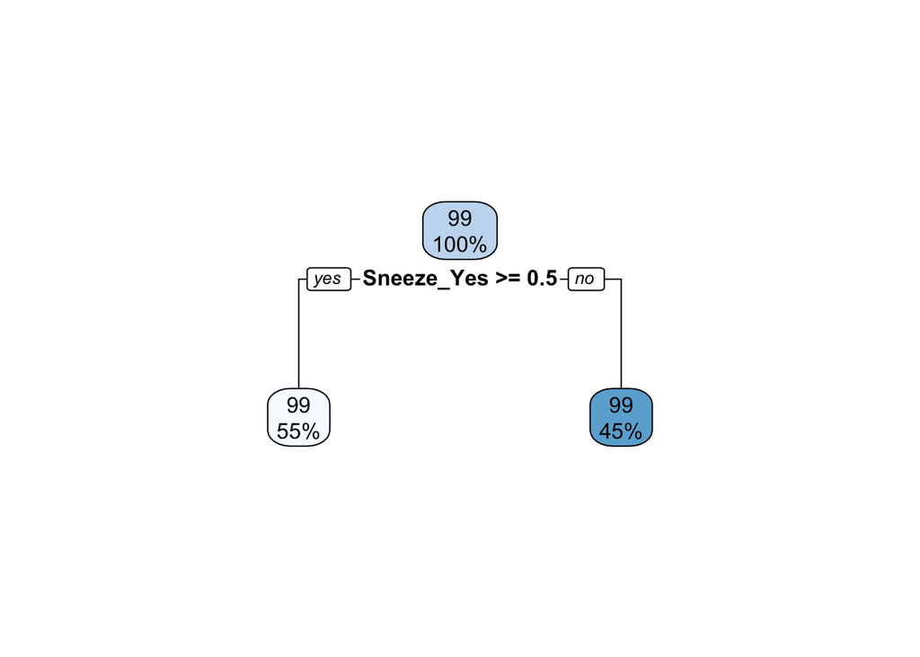

```r
rpart.plot(extract_fit_parsnip(final_fit)$fit)
```

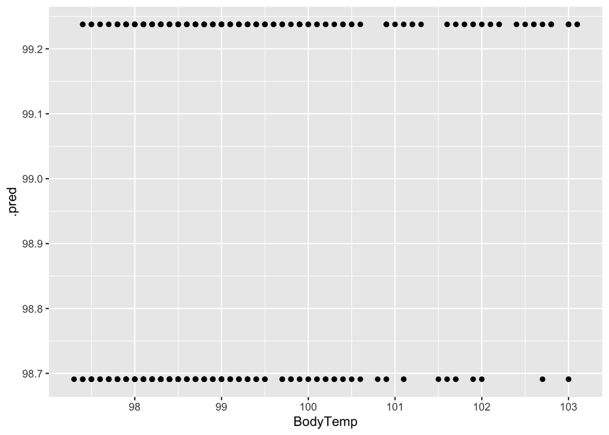

```r
# simple one-liner code used from Dr. Handel

# lets compare the residuals
#calculating residuals, code barrowed from my classmate Zane
tree_resid <- final_fit %>%
  augment(train_data) %>%
  select(.pred, BodyTemp) %>%
  mutate(.resid = BodyTemp - .pred) #manually calculate residuals

# prediction vs. truth
ggplot(tree_resid, aes(x = BodyTemp, y = .pred)) + geom_point()
```

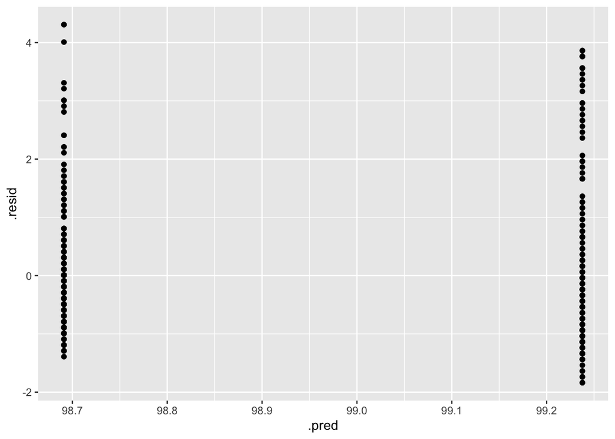

```r
# plotting residuals v. prediction
ggplot(data=tree_resid, aes(x=.pred , y=.resid)) +
  geom_point()
```

################################ LASSO ################################ sources: https://www.tidymodels.org/start/case-study/ https://stackoverflow.com/questions/66639452/tuning-a-lasso-model-and-predicting-using-tidymodels

## Building model

```r
# create model
lasso.mod <- linear_reg() %>%
  set_mode("regression") %>%
  set_engine("glmnet") %>%
  set_args(penalty = tune(), mixture = 1) #mixture = 1 means we use the LASSO model
# set workflow
lasso.wflow <- workflow() %>%
    add_model(lasso.mod) %>%
    add_recipe(D.BodyTemp.rec)
```

## Train and tune LASSO

### Setting cores

Taken from Dr. Handel, prevents my my session from aborting

```r
cores <- parallel::detectCores()
cores
```

```
## [1] 4
```

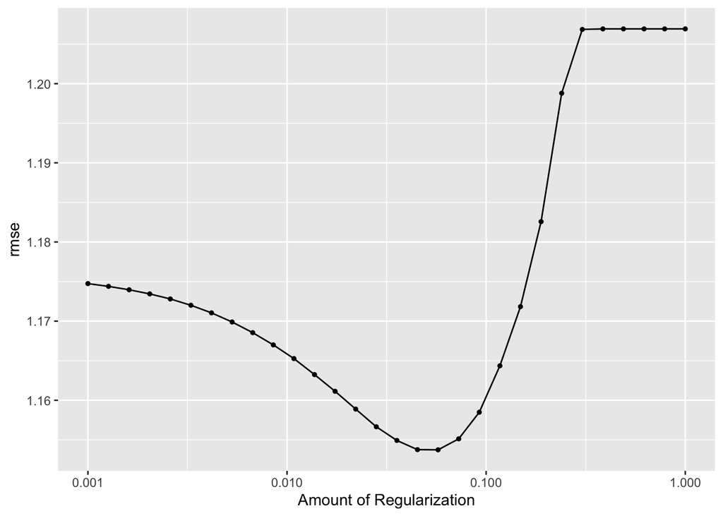

```r
ncores = 2
cl <- makePSOCKcluster(ncores)
registerDoParallel(cl)

# creating grid and tuning
lr_reg_grid <- tibble(penalty = 10^seq(-3, 0, length.out = 30))

# tuning on training data
lasso.res <- lasso.wflow %>%
  tune::tune_grid(resamples = folds,
            grid = lr_reg_grid,
            control = control_grid(verbose = TRUE, save_pred = TRUE),
            metrics = metric_set(rmse))
# turn off parallel cluster
lasso.res %>% autoplot()
```

```r
stopCluster(cl)
```

## Choosing the best performing model

```r
lasso.top.models <- lasso.res %>%
  select_best("rmse")
# finalize workflow with the best model
best.lasso.wflow <- lasso.wflow %>%
  finalize_workflow(lasso.top.models)
# fitting best performing model
best.lasso.fit <- best.lasso.wflow %>%
  fit(data = train_data)
lasso.pred <- predict(best.lasso.fit, train_data)
lasso.res %>% show_best(n = 1)
```

```
## # A tibble: 1 × 7
##   penalty .metric .estimator  mean     n std_err .config
##     <dbl> <chr>   <chr>      <dbl> <int>   <dbl> <chr>
## 1  0.0574 rmse    standard    1.15    25  0.0169 Preprocessor1_Model18
```

```r
# RMSE = 1.153742
```

## Plotting performance

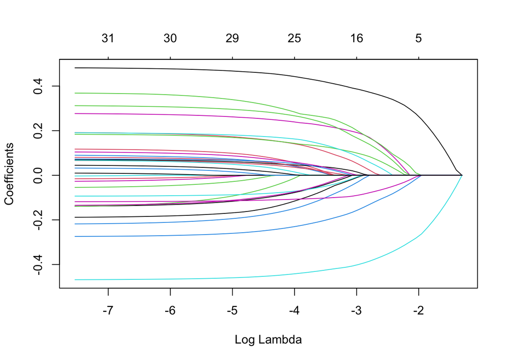

```r
# This code is borrowed from Dr. Handel
# Variables and tuning perameters
x <- best.lasso.fit$fit$fit$fit
plot(x, "lambda")
```

Random Forrest

sources: https://www.tidymodels.org/start/case-study/ https://stackoverflow.com/questions/65370000/tidymodels-a-plot-showing-performance-model-metrics-rmse-rsq-for-a-random-f

```r
# Create model
rf.mod <- rand_forest() %>%
  set_args(mtry = tune(), min_n = tune(), trees = tune()) %>%
  set_engine("ranger", num.threads = 4, importance = "permutation") %>%
  set_mode("regression")
```

## Create recipe and workflow

```r
rf.wflow <-
  workflow() %>%
  add_model(rf.mod) %>%
  add_recipe(D.BodyTemp.rec)
```

# Train and tune

```r
# prevent R from crashing
ncores = 4
cl <- makePSOCKcluster(ncores)
registerDoParallel(cl)

# tuning grid. Code from Dr. Handel
rf.grid  <- expand.grid(mtry = c(3, 4, 5, 6), min_n = c(40,50,60), trees = c(500,1000))
rf.mod %>% parameters()
```

```
## Collection of 3 parameters for tuning
##
##  identifier  type    object
##        mtry  mtry nparam[?]
##       trees trees nparam[+]
##       min_n min_n nparam[+]
##
## Model parameters needing finalization:
##    # Randomly Selected Predictors ('mtry')
##
## See `?dials::finalize` or `?dials::update.parameters` for more information.
```

```r
# space-filling design to tune, with 25 candidate models
rf.res <- rf.wflow %>%
   tune:: tune_grid(resamples = folds,
        grid = rf.grid,
        metrics = metric_set(rmse))

# turn off parallel cluster
stopCluster(cl)
```

## Evaluation

```r
rf.best <- rf.res %>%
  select_best(metric = "rmse")
# Now to fit
rf.best.wflow <- rf.wflow %>%
  finalize_workflow(rf.best)
rf.best.fit <- rf.best.wflow %>%
  fit(data = train_data)
rf_pred <- predict(rf.best.fit, train_data)
rf.res %>% show_best(n=1)
```

```
## # A tibble: 1 × 9
##    mtry trees min_n .metric .estimator  mean     n std_err .config
##   <dbl> <dbl> <dbl> <chr>   <chr>      <dbl> <int>   <dbl> <chr>
## 1     6   500    60 rmse    standard    1.16    25  0.0168 Preprocessor1_Model12
```

RMSE = 1.162239

## Visualization

```r
rf.res %>% show_best(metric = "rmse")
```

```
## # A tibble: 5 × 9
##    mtry trees min_n .metric .estimator  mean     n std_err .config
##   <dbl> <dbl> <dbl> <chr>   <chr>      <dbl> <int>   <dbl> <chr>
## 1     6   500    60 rmse    standard    1.16    25  0.0168 Preprocessor1_Model12
## 2     5  1000    60 rmse    standard    1.16    25  0.0167 Preprocessor1_Model23
## 3     6   500    50 rmse    standard    1.16    25  0.0167 Preprocessor1_Model08
## 4     6  1000    60 rmse    standard    1.16    25  0.0166 Preprocessor1_Model24
## 5     5   500    60 rmse    standard    1.16    25  0.0168 Preprocessor1_Model11
```

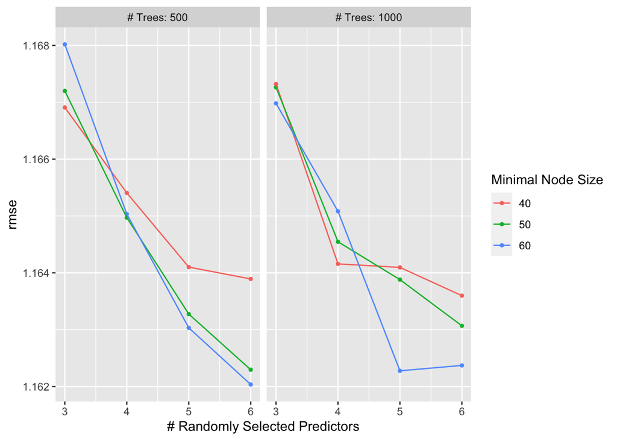

```r
autoplot(rf.res)
```

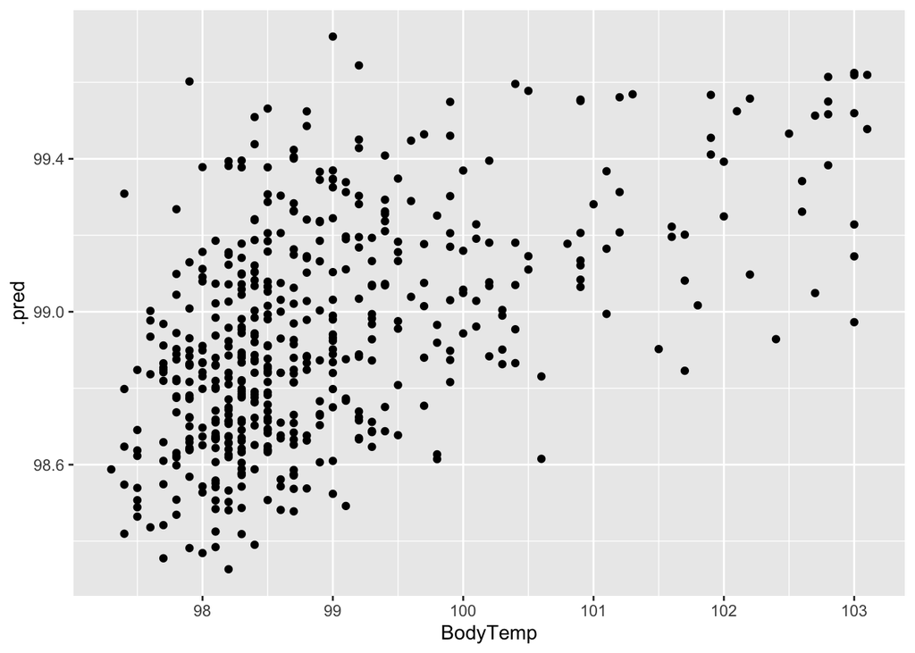

```r
# calculating residuals
rf.resid <- rf.best.fit %>%
  augment(train_data) %>% #this will add predictions to our df
  select(.pred, BodyTemp) %>%
  mutate(.resid = BodyTemp - .pred)
# plot prediction vs truth
ggplot(rf.resid, aes(x = BodyTemp, y = .pred)) +
  geom_point()
```

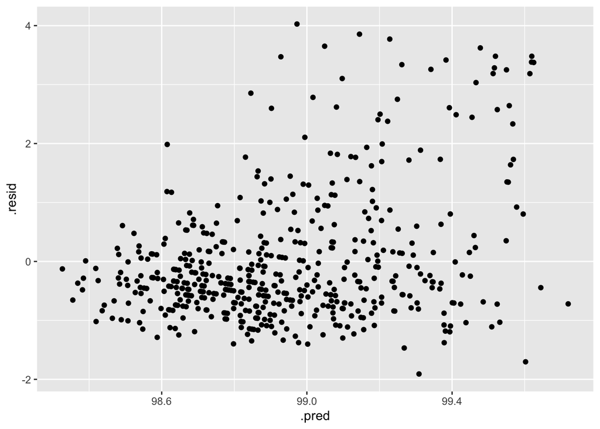

```r
# plot resid vs pred
 ggplot(rf.resid, aes(y = .resid, x = .pred)) +
   geom_point()
```

Let us figure out what type of model we should watch. Here are the RMSE of all: - Null: RMSE = 1.209 - Tree Model: RMSE = 1.193128 - LASSO: RMSE = 1.153742  
- Random Forrest: RMSE = 1.162239

# Final model.

Looks like LASSO model did the best, but not by much. I am going to run final model on Test data

```r
# fitting model
cl <- makePSOCKcluster(ncores)
registerDoParallel(cl)
# use test data
final.mod <- best.lasso.wflow %>% last_fit(data_split) # using test data
final.mod %>% collect_metrics()
```

```
## # A tibble: 2 × 4
##   .metric .estimator .estimate .config
##   <chr>   <chr>          <dbl> <chr>
## 1 rmse    standard      1.15   Preprocessor1_Model1
## 2 rsq     standard      0.0291 Preprocessor1_Model1
```

```r
# turn off parallel cluster
stopCluster(cl)
```

RMSE = 1.15474782, not much better than our null, Almost the same as training LASSO model ## Visualization

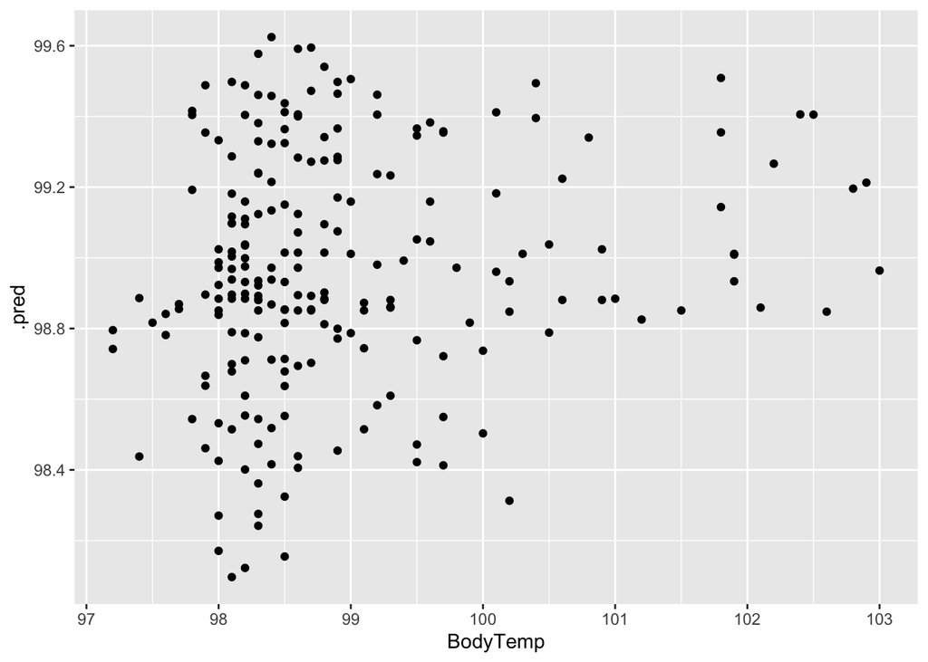

```r
# residuals
final.res <- final.mod %>%
  augment() %>%
  select(.pred, BodyTemp) %>%
  mutate(.resid = BodyTemp - .pred)

# training vs truth
ggplot(final.res, aes(x = BodyTemp, y = .pred)) +
  geom_point()
```

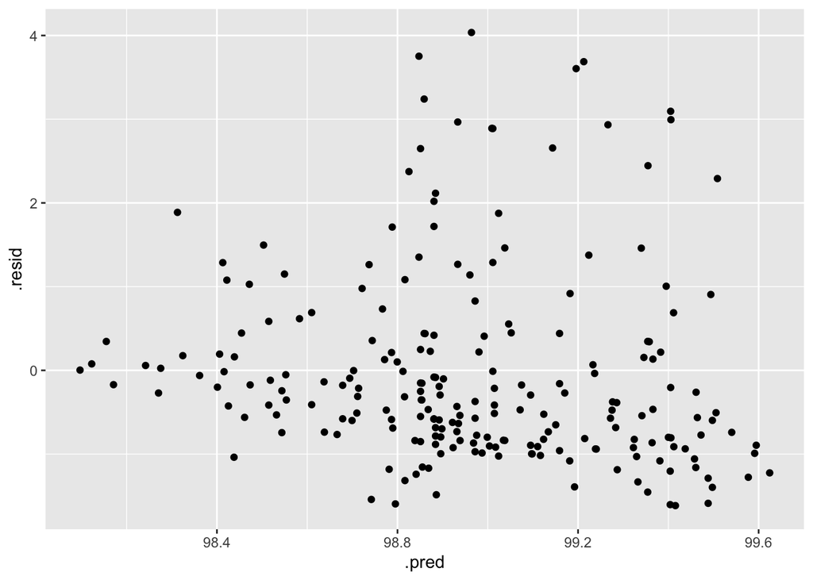

```r
# residuals vs trth
ggplot(final.res, aes(y = .resid, x = .pred)) +
  geom_point()
```

```r
#compare to null model
```